# event study bnps and apartments, moves and disadvantage

Devraj Kori

3/13/2020

Event study possible specification
$$Y_{i,ht} = \sum_{\tau=-q}^m(\beta_{\tau}D^{\tau}_{i,h,t}) + \theta_{h} + \psi_t + \epsilon_{i,h,t}$$

- $Y_{i,h,t}$ is equal to 1 if individual i in neighborhood h moves in time t.
- $\tau$ is an event-time indicator which is equal to the difference between year t and the year that the apartment was constructed.
- $D^{\tau}_{i,h,t}$ is a set of event-time dummies equal to 1 if individual i in neighborhood h is within the treatment range around the location of the new apartment.
- $\theta_h$ represents neighborhood fixed-effects
- $\psi_t$ represents year fixed effects
- $\epsilon_{i,h,t}$ is the error term, which should be uncorrelated with the other terms.
- If there is a causal effect of the construction of a new apartment on displacement of nearby voucher residents, then the $\beta_{\tau}$ values will be close to zero for values of $\tau$ less than zero, and will be positive for values of $\tau$ greater than 0.
- Untreated observations for a given event serve as the control, most rows will be untreated
- The treatment range will be a ring around each new apartment location
- Rows are repeated for each event where an individual is treated. If individual i’s location in year t is in the treatment range for two different events, the rows corresponding to i and t will be repeated for each event, with different taus assigned depending on when each apartment opened.
- Some rows will be eliminated if we can identify that individuals have been forcibly displaced prior to the construction of an apartment (i.e, if forced out by a landlord to make room for new construction)

```r
#define ring around the apartment that we'll consider the "treatment area"
 #creating a ring so that move-outs from whatever building existed on the same plot of land the apartment is on arent' included

#distances in meters
inner_distance<-25%>%units::set_units(m)
outer_distance<-500%>%units::set_units(m)

#define binning, the maximum number of years before/after an opening to include
#specify years prior as negative number
years_prior<-(-6)
years_after<-(6)

#set Tau to normalize around (Tau that is forced to be 0)
zero_tau=(-1)


#specify max repeated treatments of a given row
max_repeated_treatments<-3

#selct neighborhoods to include
included_neighborhoods<-c("East Liberty", "Homewood","Homewood West", "Homewood South","Homewood North",
                          "Larimer","Point Breeze","Point Breeze North", "East Hills", "Swisshelm Park",
                          "Shadyside", "Squirrel Hill North", "Squirrel Hill South", "Garfield", "Bloomfield",
                          "Highland Park", "Morningside",
                          "Greenfield", "Hazelwood","Glen Hazel", "Lincoln-Lemington-Belmar",
                          "Lower Lawrenceville", "Upper Lawrenceville", "Central Lawrenceville",
                          "Morningside", "Stanton Heights")

races_included<-c("Black/African American",
                  "Multi-Racial",
                  "Asian",
                  "Native Hawaiian/Other Pacific Islander",
                  "American Indian/Alaska Native",
                  "White")
#races_included<-"Black/African American"
#included_neighborhoods<-c("East Liberty","Homewood")
```

```r
# #read in new apartment complex data
# new_apartments<-read_csv("New Pgh Apartments - Large market-rate apts since 1999 - cleaned.csv")%>%
#   #remove NAS
#   filter(!is.na(lon))%>%
#   #make it sf object
#   st_as_sf(coords=c("lon","lat"),crs = "+init=epsg:4326")
#read in the bnps
# load("bnps re-geocoded.Rdata")
# bnps<-bnps_recoded
load("combined apartments commercial bnps.Rdata")

#read in zoning data
zoning<-read_sf("zoning/zoning.geojson")%>%
  select(full_zoning_type)

#read in east end moves for disadvantage
load("east end moves.Rdata")

#move the directory up a level (outside "quantitative analysis into main folder)
setwd("..")

load("cleaned and geocoded data 01-April.Rdata")

#load pittsburgh neighborhood shapefile
neighborhoods<-read_sf("data preparation/geocode addresses/Neighborhoods_/Neighborhoods_.shx")%>%
  select(hood,geometry)

#limit apartments/bnps combined to just selected neighborhoods
combined<-apartments_commercial_bnps%>%
  st_join(neighborhoods,st_within)%>%
  filter(hood%in%included_neighborhoods)%>%
  select(-hood)%>%
  #remove affordable-only
  filter(Type!="Affordable Only")%>%
  #arrange by year (so assigning event dummies will be sequential)
  arrange(`Date-Completed`)
```

```
## although coordinates are longitude/latitude, st_within assumes that they are planar
```

```r
#change the type for Rippey street to Mixed income
combined[combined$Development.Projects=="Rippey Apartment Complex",]$Type<-"Mixed-income"
combined[combined$Development.Projects=="East Mall Apartments",]$Type<-"Mixed-income"
#join dat_cleaned5 with
geocoded_data<-cleaned_and_geocoded%>%
  #remove NA move-outs, since this version is only looking at displacements
  filter(!is.na(MOVEOUTDATE))%>%
  select(HA, CLIENT_ID, GENDER, RACE, MOVEINDATE, MOVEOUTDATE, PRIMARYSTREET, ZIP,hood,geometry)%>%
  filter(hood%in%included_neighborhoods)%>%
  #join with zoning data
  st_join(zoning,join=st_within)%>%
  filter(RACE%in%races_included)
```

```
## although coordinates are longitude/latitude, st_within assumes that they are planar
```

```r
#join dat_cleaned5 with
disadvantages<-moves%>%
  st_as_sf()%>%
  filter(start_hood%in%included_neighborhoods)%>%
  #join with zoning data
  st_join(zoning,join=st_within)%>%
  filter(race%in%races_included)%>%
  # add a year column
  mutate(t=as.numeric(format(moveout_date,"%Y")))%>%
  #add field for disadvantage change, which will be the outcome
  mutate(disadvantage_change=end_disadvantage-start_disadvantage)
```

```
## although coordinates are longitude/latitude, st_within assumes that they are planar
```

Create a year dataset, where each row corresponds to all of the instances of people living in an apartment in a given year

```r
year_range<-2003:2019
for(year in year_range){
  year_frame<-geocoded_data%>%
    #create movein and moveout year variables to filter by
    mutate(movein_year=as.numeric(format(MOVEINDATE,"%Y")),
           moveout_year=as.numeric(format(MOVEOUTDATE,"%Y")))%>%
    #filter to only include rows where the stay includes that year
    filter(movein_year<=year & moveout_year<=year)%>%
    #create a flag indicating if they moved out in that year
    mutate(moved_out=(moveout_year==year))%>%
    #add a year column
    mutate(t=year)%>%
    #if an individual moves during a year, we only want the first instance of them moving, so only grab row corresponding to the earlier move-in date
    group_by(CLIENT_ID,t)%>%
    slice(which.min(MOVEINDATE))%>%
    ungroup()%>%
    #remove move-in/move-out fields since they're not relevant in this structure
    select(-c(MOVEINDATE,MOVEOUTDATE,movein_year,moveout_year))%>%
      #create address field
      mutate(address=paste(PRIMARYSTREET,ZIP))%>%
      #get rid of PRIMARY STREET AND ZIP
      select(-c(PRIMARYSTREET,ZIP))

  #bind results
  if(year==year_range[1]){
    panel_frame<-year_frame
  }else{
    panel_frame<-rbind(year_frame,panel_frame)
  }
}
```

```r
#calculate distances between new apartments and geocoded data
distances_moves<-st_distance(combined$geometry,
                       panel_frame$geometry)

#limit to just addresses that fall within specified range of each new apartment
in_range_moves<-which(distances_moves>=inner_distance & distances_moves<=outer_distance,arr.ind=TRUE)%>%as.data.frame

#remove distances to preserve memory
#rm(distances)
```

```r
#calculate distances between new apartments and geocoded data
distances_disadvantages<-st_distance(combined$geometry,
                       disadvantages$geometry)

#limit to just addresses that fall within specified range of each new apartment
in_range_disadvantages<-which(distances_disadvantages>=inner_distance & distances_disadvantages<=outer_distance,arr.ind=TRUE)%>%as.data.frame

#remove distances to preserve memory
#rm(distances)
```

```r
# the maximum number of treatments for moves and disadvantages, count by counting the number of distinct columns for each column value in in_range_moves / in_range_disadvantages
max_treated_moves<-in_range_moves%>%
  group_by(col)%>%
  summarise(treatments=n_distinct(row))%>%
  ungroup()%>%
  select(treatments)%>%
  max()
max_treated_disadvantage<-in_range_disadvantages%>%
  group_by(col)%>%
  summarise(treatments=n_distinct(row))%>%
  ungroup()%>%
  select(treatments)%>%
  max()
```

```r
#unlike tall event_frame function, this one needs to
  #1.) iterate through each row of panel_frame that's treated at least once
  #2.) for each treated row, find all events that treat that row, progressively add event taus
  #3.) translate event taus to dummies

#create vector of treated rows for moves
treated_rows_moves<-unique(in_range_moves$col)

#create vector of treated rows for disadvantages
treated_rows_disadvantages<-unique(in_range_disadvantages$col)

#create a function that takes as arguments:
  #1.) a row id corresponding to either panel_frame or disadvantages
  #2.) a df (panel or disadvantages)
  #3.) the appropriate dataframe of treated rows (in_range_moves or in_range_disadvantages)


#create a function that takes a dataframe as its argument and creates dummies for each tau value


event_dummy_function<-function(i,df,in_range){
  #limit to given row of df, strip geometry with as.data.frame
  temp_frame<-as.data.frame(df[i,])
  #find events associated with that row
  events_for_row<-unique(in_range[in_range$col==i,]$row)

  # a for loop is sloppy here, but since treated events shouldn't be too large, the performance loss may not be too bad
  # loop through events for row, create a dummy for the given event for each
  for(j in 1:min(length(events_for_row),max_repeated_treatments)){
    #assign event index
    event_index<-events_for_row[j]
    #define apartment/BNP date
    event_year<-combined[event_index,]$`Date-Completed`%>%as.numeric()

    #create event time variable for given event
    temp_frame<-temp_frame%>%
      mutate(Tau= t-event_year)
    # if tau is within the prespecified min_max year, assign dummy for Tau, otherwise assign dummy for min/max
    # this should correctly bin endpoints
    if(temp_frame$Tau<years_prior){
      dum_name<-paste0("Tau_",j,"_",years_prior)
      temp_frame<-temp_frame%>%
        mutate(!!dum_name := 1)%>%
        select(-Tau)
    }else if(temp_frame$Tau>years_after){
      dum_name<-paste0("Tau_",j,"_",years_after)
      temp_frame<-temp_frame%>%
        mutate(!!dum_name := 1)%>%
        select(-Tau)
    }else{
      dum_name<-paste0("Tau_",j,"_",temp_frame$Tau)
      temp_frame<-temp_frame%>%
        mutate(!!dum_name := 1)%>%
        select(-Tau)
      }
  }
  return(temp_frame)
}

# #create a helper function that will be called inside the event dummy function above to create tau dummies
#
# tau_dummies<-function(df2,event_num){
#   #make tau a factor
#   df2$Tau<-factor(df2$Tau)
#   #iterate through the levels of Tau, create a dummy in a new frame named "Tau_-x" and bind to df
#   #x<-levels(df$Tau)[2]
#
#   for(x in levels(df2$Tau)){
#     dummy_frame<-data.frame(col=(df2$Tau==x))
#     #set the name to be "Event_j_x"
#     names(dummy_frame)<-paste0("Tau_",event_num,"_",x)
#     df2<-bind_cols(df2,dummy_frame)
#   }
#   df2
# }

#create a function that binds the rows of an arbitrary list, this will make the next step more readable
bind_many<-function(some_list){
  do.call(bind_rows,some_list)
}

#apply the function we just created to each treated row in the panel frame
treated_moves<-lapply(treated_rows_moves,
                      function(x) event_dummy_function(
                        i=x,
                        df=panel_frame,
                        in_range=in_range_moves))%>%
  #bind all of the rows together
  bind_many()

#apply the function to each row in the disadvantages frame
treated_disadvantage<-lapply(treated_rows_disadvantages,
                      function(x) event_dummy_function(
                        i=x,
                        df=disadvantages,
                        in_range=in_range_disadvantages))%>%
  #bind all of the rows together
  bind_many()

#find untreated rows for both moves and disadvantages to add back in
untreated_moves<-panel_frame%>%
  slice(-treated_rows_moves)

untreated_disadvantage<-disadvantages%>%
  slice(-treated_rows_disadvantages)

#create named list of nas to replace for moves and disadvantages
na_moves<-names(treated_moves)[grep("Tau",names(treated_moves))]


na_disadvantage<-names(treated_disadvantage)[grep("Tau",names(treated_disadvantage))]


#bind treated and treated moves, replace nas

#start with treated moves
for_event_study_moves<-treated_moves%>%
  #add in untreated moves
  bind_rows(untreated_moves)%>%
  mutate_at(vars(na_moves),~replace_na(., 0))

for_event_study_disadvantage<-treated_disadvantage%>%
  #add in untreated disadvantage
  bind_rows(untreated_disadvantage)%>%
  mutate_at(vars(na_disadvantage),~replace_na(.,0))

head(for_event_study_moves)
```

```
##     HA CLIENT_ID GENDER                   RACE         hood
## 1 HACP   3276631 Female Black/African American East Liberty
## 2 HACP   5446184 Female Black/African American East Liberty
## 3 HACP   6443472 Female Black/African American East Liberty
## 4 HACP  10026702   Male Black/African American      Larimer
## 5 HACP  11927501 Female Black/African American East Liberty
## 6 HACP  12443379   Male Black/African American East Liberty
##                                  full_zoning_type moved_out    t
## 1   SINGLE-UNIT ATTACHED RESIDENTIAL HIGH DENSITY     FALSE 2019
## 2   SINGLE-UNIT ATTACHED RESIDENTIAL HIGH DENSITY     FALSE 2019
## 3         MULTI-UNIT RESIDENTIAL MODERATE DENSITY     FALSE 2019
## 4                   LOCAL NEIGHBORHOOD COMMERCIAL     FALSE 2019
## 5         MULTI-UNIT RESIDENTIAL MODERATE DENSITY     FALSE 2019
## 6 RESIDENTIAL/COMMERCIAL PLANNED UNIT DEVELOPMENT     FALSE 2019
##                     address            geometry Tau_1_6 Tau_2_3 Tau_2_6
```

[output cut: 41 more lines]

```r
#create the formula for the event study

#fetch names of for_event_study_moves that contain the string Tau
taus_list<-names(for_event_study_moves)[grep("Tau",names(for_event_study_moves))]

#normalize around zero_tau of first year


norm_year_tau<-paste0("Tau_1_",zero_tau)
taus_list<-taus_list[taus_list!=norm_year_tau]

#wrap each tau list in ` ` for formula
for(i in 1:length(taus_list)){
  taus_list[i]<-paste0('`',taus_list[i],'`')
}

taus_string<-paste0(taus_list,collapse=" + ")
formula<-as.formula(paste0("moved_out~",taus_string))

test_run<-lm_robust(formula,data=for_event_study_moves,fixed_effects=t+hood+full_zoning_type,clusters=hood,
                    se_type="stata")
summary(test_run)
```

```
##
## Call:
## lm_robust(formula = formula, data = for_event_study_moves, clusters = hood,
##     fixed_effects = t + hood + full_zoning_type, se_type = "stata")
##
## Standard error type:  stata
##
## Coefficients:
##              Estimate Std. Error    t value Pr(>|t|)   CI Lower  CI Upper
## Tau_1_6    -2.112e-03   0.005716 -0.3694950  0.71514 -0.0139357 0.0097119
## Tau_2_3     8.368e-03   0.013557  0.6172370  0.54314 -0.0196772 0.0364132
## Tau_2_6    -2.142e-03   0.017867 -0.1198671  0.90563 -0.0391031 0.0348197
## Tau_3_3     5.429e-03   0.010555  0.5143601  0.61191 -0.0164059 0.0272642
## Tau_3_6     6.607e-03   0.009411  0.7020970  0.48966 -0.0128606 0.0260754
## Tau_1_3     1.012e-02   0.009660  1.0471578  0.30591 -0.0098677 0.0300989
## Tau_2_2     8.547e-03   0.014133  0.6047258  0.55128 -0.0206901 0.0377836
## Tau_2_1     4.946e-03   0.007896  0.6264093  0.53721 -0.0113881 0.0212805
## Tau_1_2    -6.725e-03   0.006799 -0.9890895  0.33291 -0.0207911 0.0073405
## Tau_3_1     1.475e-03   0.010114  0.1458432  0.88532 -0.0194481 0.0223983
## Tau_3_0     3.298e-04   0.016552  0.0199275  0.98427 -0.0339097 0.0345693
## Tau_1_1    -2.589e-04   0.005340 -0.0484825  0.96175 -0.0113057 0.0107879
## Tau_3_4    -1.721e-02   0.013254 -1.2987739  0.20689 -0.0446307 0.0102038
## Tau_3_2    -1.464e-02   0.012428 -1.1779665  0.25085 -0.0403477 0.0110692
## Tau_2_0    -1.011e-02   0.012453 -0.8119076  0.42517 -0.0358729 0.0156508
## Tau_2_4     2.452e-02   0.012430  1.9725828  0.06068 -0.0011942 0.0502320
## Tau_1_5    -4.672e-03   0.008132 -0.5744802  0.57122 -0.0214948 0.0121511
## Tau_2_5     5.766e-03   0.015271  0.3775622  0.70922 -0.0258249 0.0373565
## Tau_3_5     3.069e-02   0.011761  2.6098044  0.01566  0.0063646 0.0550252
## `Tau_3_-1`  7.437e-03   0.012757  0.5829659  0.56559 -0.0189533 0.0338274
## Tau_1_0     9.967e-03   0.009025  1.1043551  0.28086 -0.0087026 0.0286358
## `Tau_2_-1`  1.809e-03   0.014191  0.1275142  0.89964 -0.0275458 0.0311648
## Tau_1_4    -1.181e-02   0.015330 -0.7706105  0.44878 -0.0435264 0.0198993
## `Tau_3_-2`  1.094e-02   0.013131  0.8327826  0.41353 -0.0162280 0.0380982
## `Tau_2_-2`  2.039e-03   0.014389  0.1416867  0.88856 -0.0277266 0.0318040
## `Tau_3_-3` -1.464e-02   0.014364 -1.0192645  0.31868 -0.0443543 0.0150733
## `Tau_1_-2`  1.749e-02   0.008259  2.1183123  0.04517  0.0004101 0.0345792
## `Tau_2_-3` -1.711e-03   0.017706 -0.0966625  0.92383 -0.0383390 0.0349160
## `Tau_3_-4`  1.012e-02   0.011901  0.8501087  0.40403 -0.0145017 0.0347356
## `Tau_1_-3`  4.509e-03   0.021446  0.2102295  0.83534 -0.0398552 0.0488722
## `Tau_2_-4`  2.735e-02   0.010491  2.6072672  0.01575  0.0056506 0.0490552
```

[output cut: 35 more lines]

```
## `Tau_2_-3` 23
## `Tau_3_-4` 23
## `Tau_1_-3` 23
## `Tau_2_-4` 23
## `Tau_3_-5` 23
## `Tau_1_-4` 23
## `Tau_2_-5` 23
## `Tau_3_-6` 23
## `Tau_1_-5` 23
## `Tau_2_-6` 23
## `Tau_1_-6` 23
##
## Multiple R-squared:  0.1967 ,    Adjusted R-squared:  0.1953
## Multiple R-squared (proj. model):  0.0007846 ,   Adjusted R-squared (proj. model):  -0.0009554
## F-statistic (proj. model):    NA on 38 and 23 DF,  p-value: NA
```

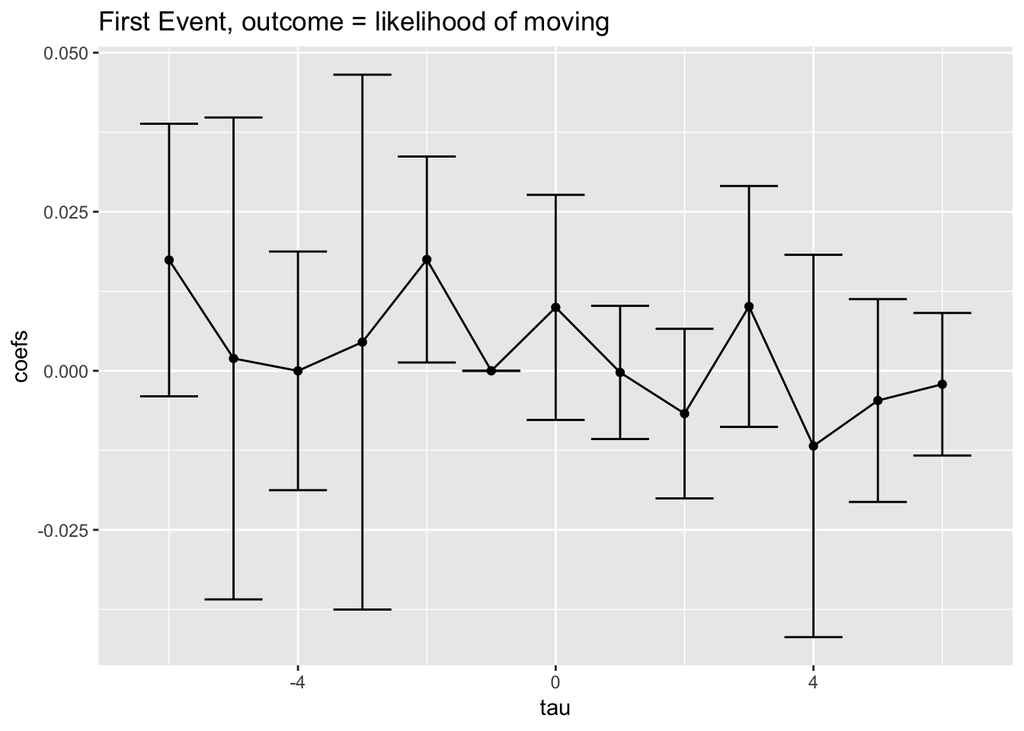

```r
#find indices of taus for first event treating each row
first_event_indices<-grep("Tau_1",names(test_run$coefficients))
data.frame(coefs=test_run$coefficients[first_event_indices],
           tau_string=names(test_run$coefficients)[first_event_indices],
           #specify range as 1.96*sd
           error=test_run$std.error[first_event_indices]*1.96)%>%
  #add in the zero tau
  rbind(data.frame(coefs=0,
                   tau_string=paste0('`',norm_year_tau,'`'),
                   error=0))%>%
  #make tau numeric
  mutate(tau_string=gsub('`','',tau_string),
         tau=as.numeric(gsub('Tau_._','',tau_string)))%>%
  ggplot(aes(x=tau,y=coefs))+
  geom_point(aes(x=tau,y=coefs))+
  geom_line()+
  geom_errorbar(aes(ymin=coefs-error,ymax=coefs+error))+
  labs(title="First Event, outcome = likelihood of moving")
```

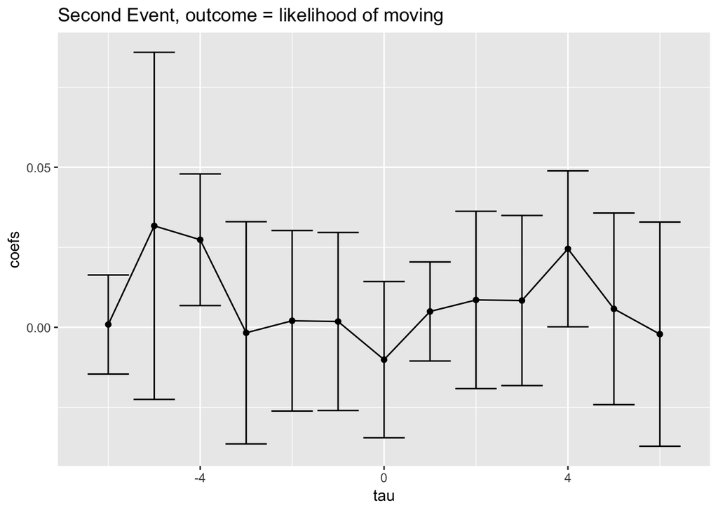

```r
#find indices of taus for first event treating each row
first_event_indices<-grep("Tau_2",names(test_run$coefficients))
data.frame(coefs=test_run$coefficients[first_event_indices],
           tau_string=names(test_run$coefficients)[first_event_indices],
           #specify range as 1.96*sd
           error=test_run$std.error[first_event_indices]*1.96)%>%
  #make tau numeric
  mutate(tau_string=gsub('`','',tau_string),
         tau=as.numeric(gsub('Tau_._','',tau_string)))%>%
  ggplot(aes(x=tau,y=coefs))+
  geom_point(aes(x=tau,y=coefs))+
  geom_line()+
  geom_errorbar(aes(ymin=coefs-error,ymax=coefs+error))+
  labs(title="Second Event, outcome = likelihood of moving")
```

```r
#create the formula for the event study

#fetch names of for_event_study_moves that contain the string Tau
taus_list<-names(for_event_study_disadvantage)[grep("Tau",names(for_event_study_disadvantage))]

#normalize around zero_tau of first year


norm_year_tau<-paste0("Tau_1_",zero_tau)
taus_list<-taus_list[taus_list!=norm_year_tau]

#wrap each tau list in ` ` for formula
for(i in 1:length(taus_list)){
  taus_list[i]<-paste0('`',taus_list[i],'`')
}
taus_string<-paste0(taus_list,collapse=" + ")
formula<-as.formula(paste0("disadvantage_change~",taus_string))

test_run<-lm_robust(formula,data=for_event_study_disadvantage,
                    fixed_effects=t+start_hood+full_zoning_type,clusters=start_hood,se_type="stata")
summary(test_run)
```

```
##
## Call:
## lm_robust(formula = formula, data = for_event_study_disadvantage,
##     clusters = start_hood, fixed_effects = t + start_hood + full_zoning_type,
##     se_type = "stata")
##
## Standard error type:  stata
##
## Coefficients:
##             Estimate Std. Error  t value  Pr(>|t|)  CI Lower   CI Upper DF
## Tau_1_6    -0.026901   0.027823  -0.9669 3.437e-01 -0.084458  0.0306558 23
## `Tau_2_-5`  0.020629   0.021828   0.9451 3.544e-01 -0.024524  0.0657833 23
## `Tau_3_-6` -0.025827   0.006288  -4.1074 4.308e-04 -0.038834 -0.0128191 23
## Tau_1_1    -0.011902   0.018833  -0.6319 5.337e-01 -0.050862  0.0270583 23
## `Tau_2_-4`  0.018468   0.018794   0.9827 3.360e-01 -0.020410  0.0573473 23
## Tau_2_0     0.038898   0.015940   2.4403 2.279e-02  0.005924  0.0718716 23
## Tau_2_3     0.070918   0.017992   3.9417 6.501e-04  0.033700  0.1081370 23
## Tau_2_6     0.117723   0.018300   6.4331 1.452e-06  0.079867  0.1555789 23
## Tau_3_6    -0.114015   0.010538 -10.8197 1.694e-10 -0.135813 -0.0922157 23
## Tau_1_0    -0.052295   0.025698  -2.0350 5.354e-02 -0.105455  0.0008656 23
## `Tau_2_-3`  0.012460   0.012656   0.9845 3.351e-01 -0.013721  0.0386401 23
## `Tau_3_-4` -0.061761   0.010921  -5.6554 9.321e-06 -0.084352 -0.0391696 23
## `Tau_1_-6` -0.016255   0.011383  -1.4280 1.667e-01 -0.039803  0.0072925 23
## Tau_1_4    -0.028642   0.036674  -0.7810 4.428e-01 -0.104508  0.0472247 23
## `Tau_2_-6` -0.009408   0.010612  -0.8865 3.845e-01 -0.031361  0.0125450 23
## Tau_3_1    -0.087288   0.011194  -7.7976 6.638e-08 -0.110445 -0.0641308 23
## `Tau_3_-3` -0.041147   0.014778  -2.7843 1.054e-02 -0.071718 -0.0105756 23
## Tau_2_4     0.100241   0.015033   6.6683 8.389e-07  0.069144  0.1313379 23
## Tau_3_2    -0.047304   0.012460  -3.7964 9.315e-04 -0.073079 -0.0215277 23
## `Tau_2_-2`  0.034367   0.017277   1.9892 5.870e-02 -0.001373  0.0701076 23
## `Tau_3_-5` -0.067317   0.012452  -5.4063 1.712e-05 -0.093075 -0.0415589 23
## Tau_3_3    -0.086629   0.009719  -8.9132 6.396e-09 -0.106734 -0.0665230 23
## Tau_3_0    -0.072837   0.016913  -4.3066 2.622e-04 -0.107824 -0.0378505 23
## Tau_1_5    -0.024868   0.016897  -1.4717 1.546e-01 -0.059822  0.0100864 23
## Tau_1_2    -0.006102   0.022008  -0.2772 7.841e-01 -0.051629  0.0394258 23
## `Tau_3_-1` -0.029141   0.010589  -2.7519 1.135e-02 -0.051046 -0.0072350 23
## Tau_3_5    -0.064916   0.013660  -4.7523 8.630e-05 -0.093174 -0.0366588 23
## `Tau_1_-4` -0.032710   0.020589  -1.5887 1.258e-01 -0.075302  0.0098826 23
## `Tau_1_-5`  0.004941   0.014156   0.3491 7.302e-01 -0.024342  0.0342250 23
## `Tau_1_-3` -0.023379   0.019928  -1.1732 2.527e-01 -0.064603  0.0178452 23
## `Tau_3_-2` -0.050761   0.024607  -2.0629 5.059e-02 -0.101664  0.0001416 23
## `Tau_1_-2` -0.013907   0.013704  -1.0148 3.208e-01 -0.042257  0.0144426 23
## Tau_2_5     0.126741   0.017625   7.1910 2.540e-07  0.090281  0.1632010 23
## `Tau_2_-1`  0.056915   0.016946   3.3586 2.717e-03  0.021860  0.0919705 23
## Tau_2_1     0.062694   0.026051   2.4066 2.453e-02  0.008803  0.1165841 23
## Tau_2_2     0.052429   0.010602   4.9454 5.341e-05  0.030498  0.0743601 23
## Tau_1_3    -0.014248   0.031556  -0.4515 6.559e-01 -0.079527  0.0510310 23
## Tau_3_4    -0.069228   0.014621  -4.7349 9.013e-05 -0.099474 -0.0389829 23
##
## Multiple R-squared:  0.4253 ,    Adjusted R-squared:  0.4127
## Multiple R-squared (proj. model):  0.01186 , Adjusted R-squared (proj. model):  -0.009943
## F-statistic (proj. model):    NA on 38 and 23 DF,  p-value: NA
```

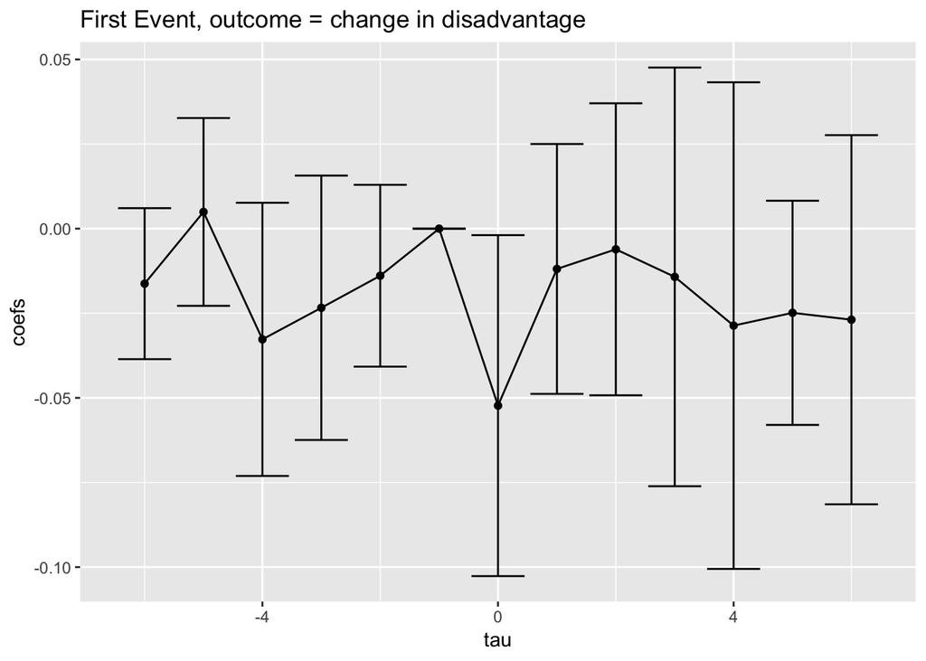

```r
#find indices of taus for first event treating each row
first_event_indices<-grep("Tau_1",names(test_run$coefficients))
data.frame(coefs=test_run$coefficients[first_event_indices],
           tau_string=names(test_run$coefficients)[first_event_indices],
           #specify range as 1.96*sd
           error=test_run$std.error[first_event_indices]*1.96)%>%
  #add in the zero tau
  rbind(data.frame(coefs=0,
                   tau_string=paste0('`',norm_year_tau,'`'),
                   error=0))%>%
  #make tau numeric
  mutate(tau_string=gsub('`','',tau_string),
         tau=as.numeric(gsub('Tau_._','',tau_string)))%>%
  ggplot(aes(x=tau,y=coefs))+
  geom_point(aes(x=tau,y=coefs))+
  geom_line()+
  geom_errorbar(aes(ymin=coefs-error,ymax=coefs+error))+
  labs(title="First Event, outcome = change in disadvantage")
```

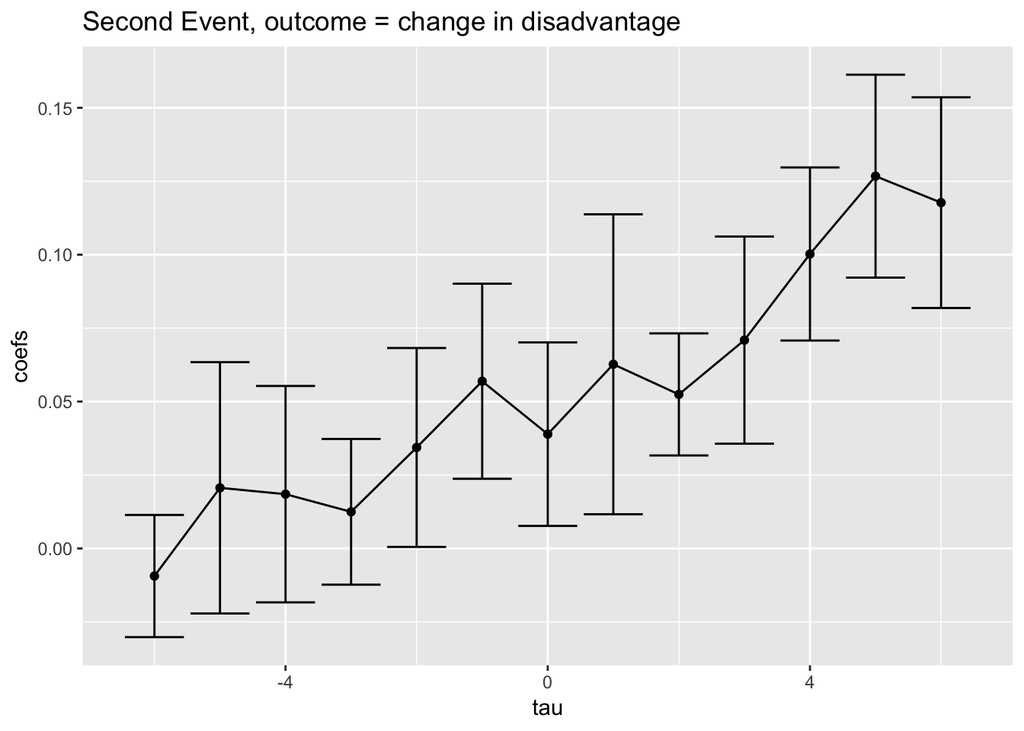

```r
#find indices of taus for first event treating each row
first_event_indices<-grep("Tau_2",names(test_run$coefficients))
data.frame(coefs=test_run$coefficients[first_event_indices],
           tau_string=names(test_run$coefficients)[first_event_indices],
           #specify range as 1.96*sd
           error=test_run$std.error[first_event_indices]*1.96)%>%
  #make tau numeric
  mutate(tau_string=gsub('`','',tau_string),
         tau=as.numeric(gsub('Tau_._','',tau_string)))%>%
  ggplot(aes(x=tau,y=coefs))+
  geom_point(aes(x=tau,y=coefs))+
  geom_line()+
  geom_errorbar(aes(ymin=coefs-error,ymax=coefs+error))+
  labs(title="Second Event, outcome = change in disadvantage")
```